# Statistical Analysis of Physical Characteristics of Palmer Penguins

Lab Problem Statement 6 — Descriptive Statistics, Hypothesis Testing, ANOVA & Non-Parametric Tests

September 12, 2026

# 1. Introduction

The Palmer Penguins dataset (Horst, Hill & Gorman; 344 penguins, 3 species: Adelie, Chinstrap, Gentoo) was analyzed to determine whether **body mass** and **flipper length** differ significantly across species and sex. After removing rows with missing values in the variables used (`species`, `sex`, `body_mass_g`, `flipper_length_mm`), **333 of 344 penguins** remained for analysis.

# 2. Descriptive Statistics — Body Mass

**Overall (n = 333):**

| Mean | Median | Min | Max | Variance | SD | Q1 | Q3 | IQR | Skewness | Kurtosis |
| --- | --- | --- | --- | --- | --- | --- | --- | --- | --- | --- |
| 4207.1 | 4050 | 2700 | 6300 | 648372.5 | 805.2 | 3550 | 4775 | 1225 | 0.47 | -0.74 |

**By species:**

| Statistic | Adelie | Chinstrap | Gentoo |
| --- | --- | --- | --- |
| Mean | 3706.2 | 3733.1 | 5092.4 |
| Median | 3700 | 3700 | 5050 |
| Min | 2850 | 2700 | 3950 |
| Max | 4775 | 4800 | 6300 |
| Variance | 210332.4 | 147713.5 | 251478.3 |
| SD | 458.6 | 384.3 | 501.5 |
| Q1 | 3362.5 | 3487.5 | 4700 |
| Q3 | 4000 | 3950 | 5500 |
| IQR | 637.5 | 462.5 | 800 |
| Skewness | 0.28 | 0.24 | 0.04 |
| Kurtosis (excess) | -0.59 | 0.46 | -0.76 |

**Interpretation:** Gentoo penguins are markedly heavier (mean ≈ 5092 g) and more variable (SD ≈ 501 g) than Adelie and Chinstrap, which are close to each other (≈3706 g and ≈3733 g respectively). Mild positive skew in all three groups reflects a slightly longer right tail; kurtosis values near zero indicate roughly normal peakedness, so no species shows strongly non-normal shape.

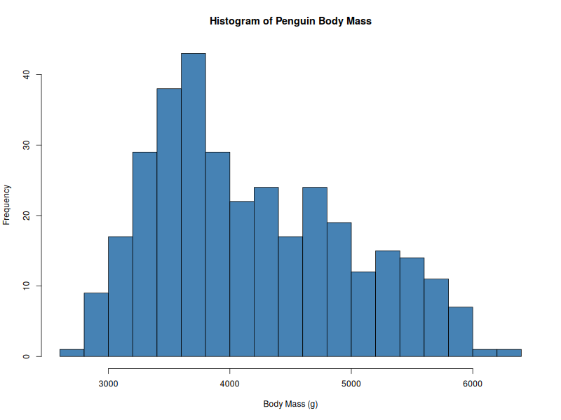

Histogram of body mass

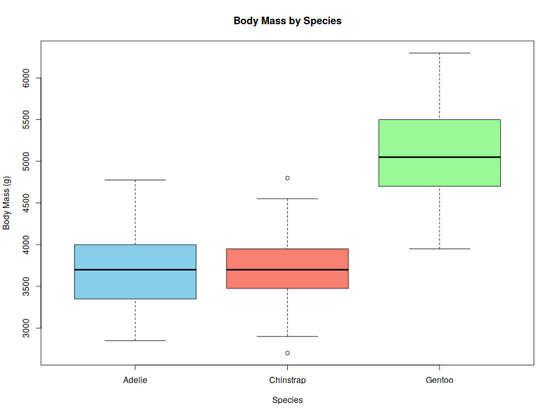

Boxplot of body mass by species

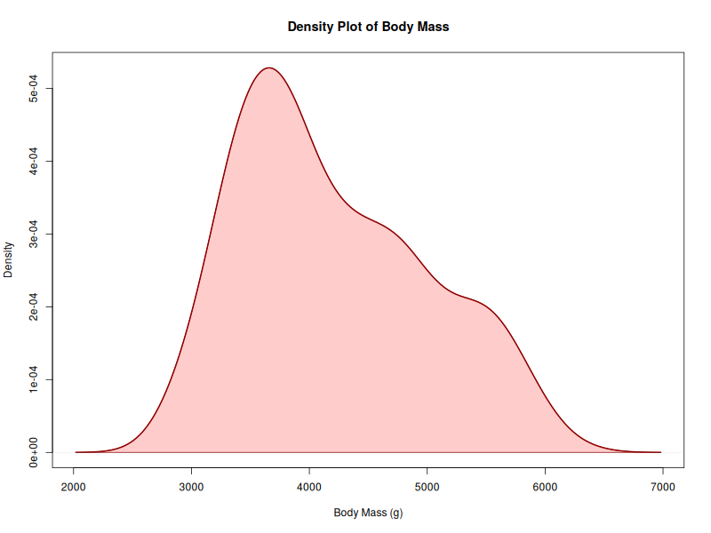

Density plot of body mass

# 3. Hypothesis Testing — Body Mass by Sex

**H0:** μ(male) = μ(female) **H1:** μ(male) ≠ μ(female)

- **Shapiro-Wilk:** male W = 0.925, p < .001; female W = 0.919, p < .001 — both reject normality, but with n = 168 (male) and n = 165 (female), the t-test remains valid by the Central Limit Theorem.
- **Levene’s test:** F(1,331) = 6.06, p = .014 — variances are **not** equal, so **Welch’s t-test** is the appropriate choice.
- **Welch two-sample t-test:** t(323.9) = 8.55, **p < .001**. Mean male mass = 4545.7 g, mean female mass = 3862.3 g, difference = 683.4 g.
- **95% CI for the difference:** [526.2, 840.6] g — does not contain 0.
- **Cohen’s d = 0.94** (large effect).

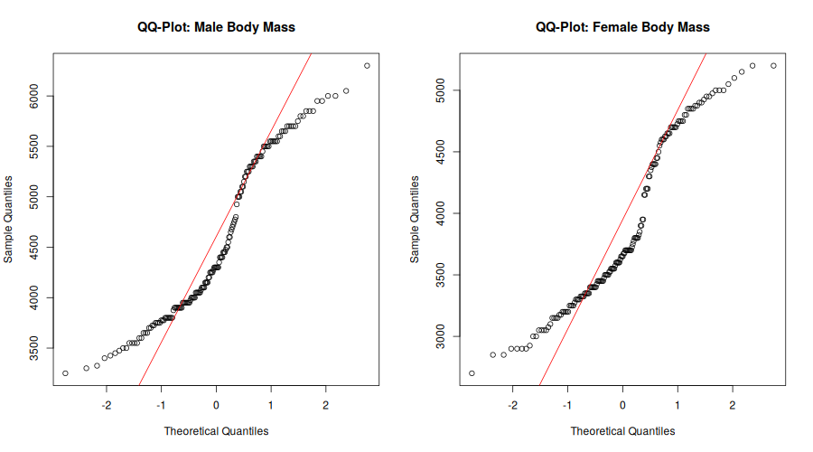

QQ-plots for male and female body mass

**Interpretation:** The extremely small p-value and a CI that excludes zero confirm a real difference in mean body mass between sexes, and Cohen’s d = 0.94 shows this is a large, practically meaningful difference, not just a statistically detectable one.

# 4. One-Way ANOVA — Body Mass by Species

- **Shapiro-Wilk per species:** Adelie p = .042, Chinstrap p = .56, Gentoo p = .26 — Adelie shows a mild deviation from normality but with n = 146 the ANOVA is robust to this.
- **Levene’s test:** F(2,330) = 5.13, p = .006 — variances differ somewhat across species, motivating the Kruskal-Wallis cross-check in Section 5.
- **ANOVA:** F(2, 330) = **341.9**, **p < .001** (species has a highly significant effect on body mass).

**Tukey HSD post-hoc:**

| Comparison | Mean Diff | 95% CI | p adj | Significant? |
| --- | --- | --- | --- | --- |
| Chinstrap − Adelie | 26.9 | [-132.4, 186.2] | .916 | No |
| Gentoo − Adelie | 1386.3 | [1252.3, 1520.3] | <.001 | Yes |
| Gentoo − Chinstrap | 1359.3 | [1194.4, 1524.3] | <.001 | Yes |

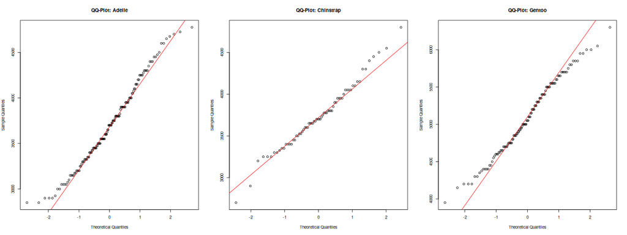

QQ-plots of body mass per species

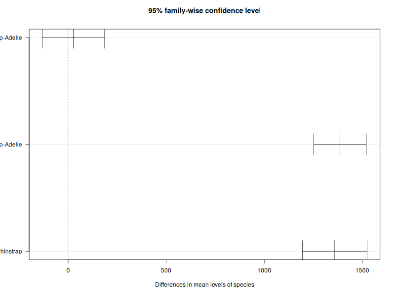

Tukey HSD 95% CIs for body mass

**Interpretation:** Gentoo is significantly heavier than both other species, while Adelie and Chinstrap are statistically indistinguishable in body mass.

# 5. Non-Parametric Analysis — Kruskal-Wallis

**Kruskal-Wallis:** χ² = 212.1, df = 2, **p < .001**.

**Comparison with ANOVA:** Both tests reach the same conclusion — species significantly affects body mass. The agreement between the parametric and non-parametric approaches shows the ANOVA result is robust despite the mild variance heterogeneity flagged by Levene’s test.

# 6. Two-Way ANOVA — Body Mass by Species × Sex

| Source | Sum Sq | df | F | p |
| --- | --- | --- | --- | --- |
| Species | 143,401,600 | 2 | 749.0 | <.001 |
| Sex | 37,090,260 | 1 | 387.5 | <.001 |
| Species:Sex | 1,676,557 | 2 | 8.76 | <.001 |
| Residuals | 31,302,630 | 327 |  |  |

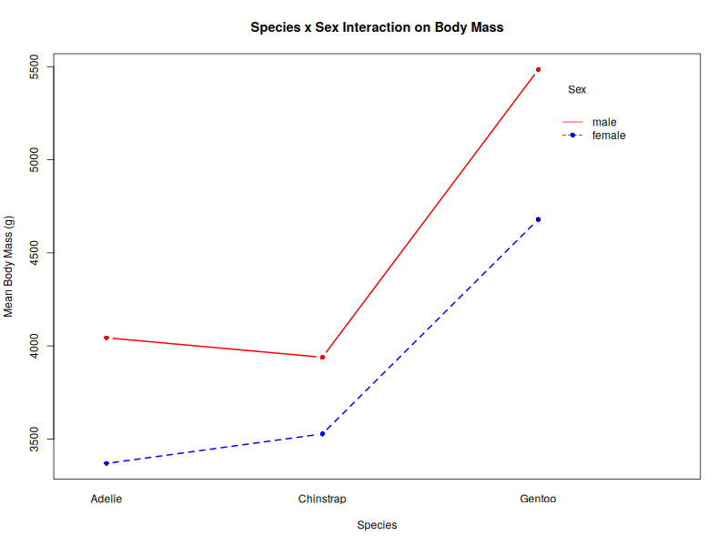

Species × sex interaction plot

**Interpretation:** Species, sex, and their interaction are all significant. Males are heavier than females within every species, but the size of that gap is not constant — it is largest in Gentoo — which is exactly what a significant interaction term captures.

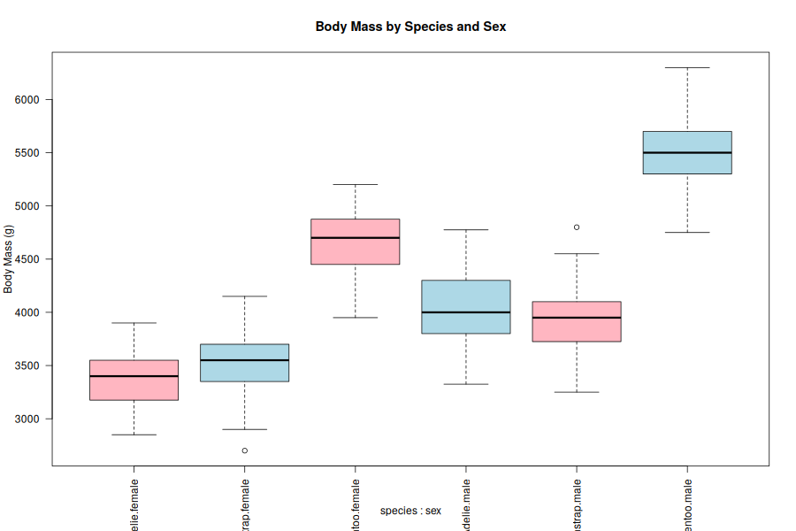

Body mass by species and sex

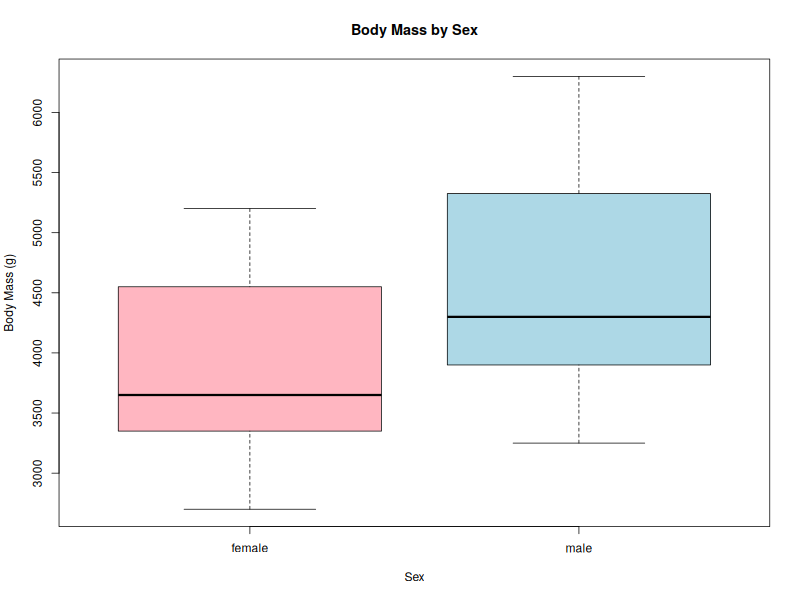

Body mass by sex

# 7. Additional Analysis — Flipper Length by Species

| Statistic | Adelie | Chinstrap | Gentoo |
| --- | --- | --- | --- |
| Mean | 190.1 | 195.8 | 217.2 |
| SD | 6.5 | 7.1 | 6.5 |
| IQR | 9.0 | 10.0 | 9.5 |

- **Levene’s test:** F(2,330) = 0.44, p = .64 — variances are equal (unlike body mass).
- **ANOVA:** F(2,330) = **567.4**, **p < .001**.
- **Kruskal-Wallis:** χ² = 237.3, **p < .001** — agrees with ANOVA.

**Tukey HSD (all three pairs significant, p < .001):**

| Comparison | Mean Diff | 95% CI |
| --- | --- | --- |
| Chinstrap − Adelie | 5.72 | [3.41, 8.03] |
| Gentoo − Adelie | 27.13 | [25.19, 29.07] |
| Gentoo − Chinstrap | 21.41 | [19.02, 23.80] |

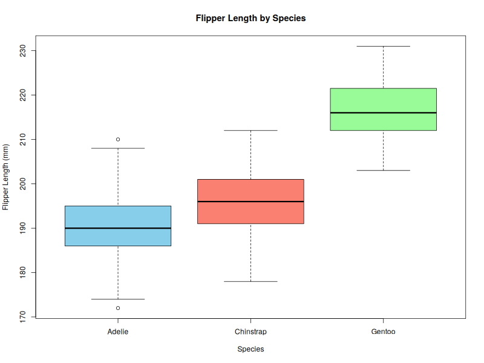

Flipper length by species

**Interpretation:** Unlike body mass, flipper length significantly separates **all three** species from one another, including Adelie vs Chinstrap. This makes flipper length a more discriminating physical trait for species identification, even though the overall species ordering (Gentoo > Chinstrap > Adelie) matches body mass.

# 8. Overall Conclusions

1. **Body mass** differs significantly by species (Gentoo >> Adelie ≈ Chinstrap) and by sex (males > females, large effect, d = 0.94), with a significant species×sex interaction — the male-female gap is largest in Gentoo.
2. **Flipper length** also differs significantly by species, and does so more completely than body mass: it distinguishes all three species pairwise, whereas body mass cannot separate Adelie from Chinstrap.
3. Parametric tests (t-test, ANOVA) and their non-parametric counterparts (Kruskal-Wallis) agree on every conclusion reached in this analysis, indicating the findings are robust to the mild normality/variance-homogeneity violations observed in a few subgroups.